# Module 7: Classification Quality Assessment

LCA for Social Science Research

2026-04-06

# 1 Purpose of This Module

Once you have selected a candidate model using fit criteria and theoretical judgment (Module 6), you must evaluate how accurately that model classifies individuals into the identified classes. This module covers the diagnostic tools that measure classification precision: posterior probabilities, entropy, the Average Latent Class Posterior Probability (ALCPP) matrix, and the Odds of Correct Classification (OCC).

These diagnostics answer a fundamentally different question than fit statistics. Fit statistics ask: “Is this the right number of classes?” Classification diagnostics ask: “Given this number of classes, how confidently can we assign individuals?” A model can be the best-fitting model in the sequence and still have poor classification quality — meaning the classes exist but are so overlapping that individuals cannot be placed into them with certainty.

Why this matters: if classification quality is low and you proceed to assign individuals to their most probable class (a “classify-analyze” approach), the resulting class variable is contaminated by measurement error. Subsequent analyses — comparisons of classes on outcomes, regression of class membership on covariates — will be biased. The diagnostics in this module tell you how much to trust the class assignments and whether additional precautions (such as the three-step approach in Module 10) are necessary.

> **Prerequisites:** This module loads objects from Modules 4, 5, and 6. Render those modules first.

```r
load("lca_prepared_data.RData")
load("lca_selected_model.RData")
load("lca_estimated_models.RData")
library(poLCA)
library(tidyverse)
library(knitr)
library(kableExtra)
```

# 2 Homogeneity and Latent Class Separation

## 2.1 Homogeneity

Homogeneity describes the extent to which individuals within a class share the same response pattern. It is assessed by examining the item-response probabilities within each class.

When item-response probabilities are near 0 or 1, most class members give the same response to that item — the class is internally consistent on that item. When probabilities are near 0.5, the item provides no diagnostic information for that class — members are equally likely to agree or disagree.

Perfect homogeneity (all probabilities at exactly 0 or 1) means every member of the class has an identical response pattern. This is unrealistic in empirical data but serves as an ideal benchmark. The closer your probabilities are to the boundaries, the better your homogeneity.

## 2.2 Latent Class Separation

Separation describes how distinct the classes are from one another. Even if each class is internally homogeneous, the classes may share similar profiles. When separation is high, a response pattern that characterizes one class has a very low probability of occurring in any other class — the classes occupy non-overlapping regions of the response space.

## 2.3 The Relationship Between the Two

High separation implies high homogeneity, but high homogeneity does not guarantee high separation. Two classes could both have item-response probabilities near 0 and 1, but if their profiles are nearly identical (e.g., both classes have the same high-probability and low-probability items), they are homogeneous but not separated. The model would struggle to distinguish between them.

Good classification requires both properties.

## 2.4 Examining Item-Response Probabilities for Homogeneity and Separation

```r
prob_table <- matrix(NA, nrow = length(best_model$P), ncol = length(item_names))
for (j in seq_along(item_names)) {
  prob_table[, j] <- best_model$probs[[item_names[j]]][, 1]
}
colnames(prob_table) <- item_names
rownames(prob_table) <- paste("Class", 1:length(best_model$P))

kable(round(prob_table, 3),
      caption = "Item-Response Probabilities: P(Agree) by Class") %>%
  kable_styling(full_width = FALSE)
```

Item-Response Probabilities: P(Agree) by Class

|  | REDIST | IMMIG | PRIDE | TRUST | TRAD | ENVIR |
| --- | --- | --- | --- | --- | --- | --- |
| Class 1 | 0.226 | 0.242 | 0.292 | 0.537 | 0.026 | 0.277 |
| Class 2 | 0.179 | 0.835 | 0.901 | 0.198 | 0.913 | 0.196 |
| Class 3 | 0.997 | 0.157 | 0.231 | 0.589 | 0.181 | 0.937 |
| Class 4 | 1.000 | 0.870 | 0.873 | 0.155 | 0.779 | 0.812 |

**Evaluating homogeneity:** For each class (row), how many probabilities are close to 0 or 1? If most are above 0.8 or below 0.2, homogeneity is high. If many are in the 0.3–0.7 range, those items are not diagnostic for that class.

**Evaluating separation:** For each item (column), how different are the probabilities across classes? If one class has 0.90 and another has 0.10 on the same item, that item strongly discriminates between those classes. If all classes have probabilities between 0.40 and 0.60 on an item, that item provides no discriminatory power.

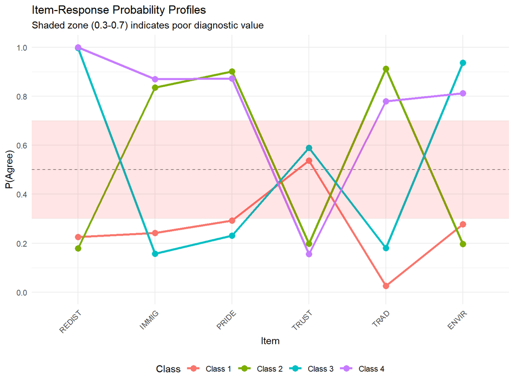

```r
# Visual assessment: profile plot colored by deviation from 0.5
prob_df <- as.data.frame(prob_table)
prob_df$Class <- factor(paste("Class", 1:nrow(prob_df)))

prob_long <- prob_df %>%
  pivot_longer(-Class, names_to = "Item", values_to = "Probability") %>%
  mutate(Item = factor(Item, levels = item_names))

ggplot(prob_long, aes(x = Item, y = Probability, color = Class, group = Class)) +
  geom_line(linewidth = 1.2) +
  geom_point(size = 3) +
  geom_hline(yintercept = 0.5, linetype = "dashed", color = "grey50") +
  scale_y_continuous(limits = c(0, 1), breaks = seq(0, 1, 0.2)) +
  annotate("rect", xmin = -Inf, xmax = Inf, ymin = 0.3, ymax = 0.7,
           alpha = 0.1, fill = "red") +
  labs(title = "Item-Response Probability Profiles",
       subtitle = "Shaded zone (0.3-0.7) indicates poor diagnostic value",
       x = "Item", y = "P(Agree)") +
  theme_minimal() +
  theme(axis.text.x = element_text(angle = 45, hjust = 1),
        legend.position = "bottom")
```

Items with probabilities in the shaded zone (0.3 to 0.7) for a given class contribute little to classifying members of that class. Items with probabilities outside the shaded zone in different directions for different classes are the primary drivers of class separation.

# 3 Posterior Probabilities

## 3.1 What They Represent

For each individual $i$ and each class $c$, the posterior probability $P(C = c \mid \mathbf{y}_i)$ is the probability that individual $i$ belongs to class $c$, given their observed response pattern. These are computed via Bayes’ theorem during the E-step of the EM algorithm (see Module 5).

For each individual, the posterior probabilities across all classes sum to 1.0. In an ideal model, each individual’s posteriors would be “peaked” — near 1.0 for one class and near 0.0 for all others, indicating unambiguous classification. In a poor model, posteriors would be “flat” — roughly equal across classes, indicating that the model cannot determine which class the individual belongs to.

```r
posterior <- best_model$posterior
assigned_class <- best_model$predclass

# Display posteriors for a random sample of 15 individuals
set.seed(77)
sample_idx <- sort(sample(1:nrow(posterior), 15))
sample_post <- data.frame(
  ID = sim_data$id[sample_idx],
  posterior[sample_idx, ],
  Assigned = assigned_class[sample_idx],
  Max_Prob = apply(posterior[sample_idx, ], 1, max)
)
names(sample_post)[2:(length(best_model$P) + 1)] <- paste0("P(Class ", 1:length(best_model$P), ")")

kable(round(sample_post, 3),
      caption = "Posterior Probabilities for 15 Sampled Individuals") %>%
  kable_styling(full_width = FALSE)
```

Posterior Probabilities for 15 Sampled Individuals

| ID | P(Class 1) | P(Class 2) | P(Class 3) | P(Class 4) | Assigned | Max_Prob |
| --- | --- | --- | --- | --- | --- | --- |
| 16 | 0.880 | 0.119 | 0.000 | 0.000 | 1 | 0.880 |
| 182 | 0.972 | 0.028 | 0.000 | 0.000 | 1 | 0.972 |
| 197 | 0.007 | 0.040 | 0.647 | 0.305 | 3 | 0.647 |
| 248 | 0.007 | 0.040 | 0.647 | 0.305 | 3 | 0.647 |
| 251 | 0.002 | 0.998 | 0.000 | 0.000 | 2 | 0.998 |
| 285 | 0.003 | 0.072 | 0.198 | 0.728 | 4 | 0.728 |
| 293 | 0.001 | 0.568 | 0.001 | 0.431 | 2 | 0.568 |
| 310 | 0.029 | 0.970 | 0.002 | 0.000 | 2 | 0.970 |
| 320 | 0.213 | 0.082 | 0.658 | 0.047 | 3 | 0.658 |
| 351 | 0.009 | 0.991 | 0.000 | 0.000 | 2 | 0.991 |
| 504 | 0.998 | 0.001 | 0.000 | 0.000 | 1 | 0.998 |
| 632 | 0.986 | 0.004 | 0.010 | 0.000 | 1 | 0.986 |
| 658 | 0.065 | 0.000 | 0.934 | 0.001 | 3 | 0.934 |
| 660 | 0.000 | 0.069 | 0.007 | 0.924 | 4 | 0.924 |
| 738 | 0.001 | 0.999 | 0.000 | 0.000 | 2 | 0.999 |

**Reading this table:** Each row is an individual. The $P(\text{Class } c)$ columns show the posterior probability of belonging to each class. The “Assigned” column shows the class with the highest posterior probability. The “Max_Prob” column shows the maximum posterior probability — values near 1.0 indicate confident classification.

## 3.2 Distribution of Maximum Posterior Probabilities

A useful diagnostic is to examine the distribution of the maximum posterior probability across all individuals. This shows how certain the model is about its classifications at the individual level.

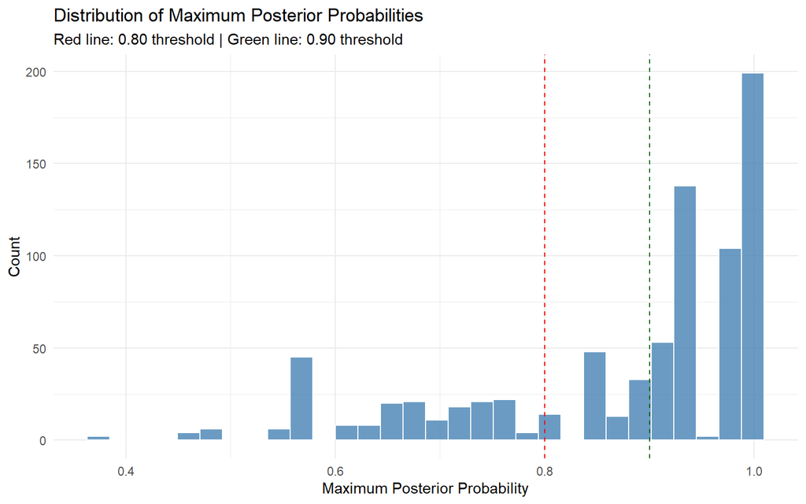

```r
max_post <- apply(posterior, 1, max)

ggplot(data.frame(max_post = max_post), aes(x = max_post)) +
  geom_histogram(bins = 30, fill = "steelblue", color = "white", alpha = 0.8) +
  geom_vline(xintercept = 0.8, linetype = "dashed", color = "red") +
  geom_vline(xintercept = 0.9, linetype = "dashed", color = "darkgreen") +
  labs(title = "Distribution of Maximum Posterior Probabilities",
       subtitle = "Red line: 0.80 threshold | Green line: 0.90 threshold",
       x = "Maximum Posterior Probability", y = "Count") +
  theme_minimal()
```

```r
cat("Proportion of individuals with max posterior > 0.90:",
    round(mean(max_post > 0.90), 3), "\n")
```

```
## Proportion of individuals with max posterior > 0.90: 0.62
```

```r
cat("Proportion of individuals with max posterior > 0.80:",
    round(mean(max_post > 0.80), 3), "\n")
```

```
## Proportion of individuals with max posterior > 0.80: 0.755
```

```r
cat("Proportion of individuals with max posterior < 0.70:",
    round(mean(max_post < 0.70), 3), "\n")
```

```
## Proportion of individuals with max posterior < 0.70: 0.16
```

Individuals with maximum posterior probabilities below 0.70 have ambiguous class membership — the model is substantially uncertain about where they belong. A large proportion of such individuals signals that the classes are not well-separated and that downstream analyses using class assignments will be biased.